# Projet BIO401-Partie 1

AmigoTeam

2024-04-07

#### Article de référence : Blackwood, J.C., Hastings, A. and Mumby, P.J. (2011), A model-based approach to determine the long-term effects of multiple interacting stressors on coral reefs. Ecological Applications, 21: 2722-2733. https://doi.org/10.1890/10-2195.1

###### Les analyses du modèle ont été faites par : Antoine Castonguay et Félix Richard

## Partie 1 :

### Question biologique :

Comment la résilience des récifs coralliens, soit la capacité à ne pas s’effondrer suite a un stress ou une perturbation varie-t-elle selon l’effort de pêche, l’impact des ouragans et la rugosité initiale?

### Hypothèse :

1. La résilience diminue quand l’effort de pêche augmente.
2. La résilience diminue quand les ouragans sont plus fréquence.
3. La résilience diminue quand les ouragans sont plus puissants.
4. La résilience diminue quand la rugosité est faible.

### Données :

#### Tableau 1 : Paramètres utilisés dans le modèle de référence et leurs définitions.

| Paramètre | Valeur | Définition |
| --- | --- | --- |
| s | 0.49 | Taux de croissance des poisson perroquets par année |
| r | 1 | Taux pour lequel le corail remplace le gazon d’algue par année |
| a | 0.1 | Taux pour lequel les macroalgues remplacent le corail par année |
| gamma | 1.6,0.8 | Taux pour lequel les macroalgues remplacent le gazon d’algue par année |
| d | 0.44 | Taux de mortalité du corail par année |
| Alpha | 1 | Taux de broutage maximal par le poisson perroquet |
| f | variable | Effort de pêche en pourcentage |
| c1,c2 | 3.65,-3.21 | Détermine la relation entre la complexité du corail et la capacité de support du poisson perroquet |
| delta,v | 4.557,0.9877 | Détermine la relation entre la nourriture disponible et la capacité de support du poisson perroquet |
| Beta | 1 | Capacité de support de l’environnement pour le poisson perroquet relatif |
| hG | 0.03 | Rétablissement de la complexité du corail par année |
| hE | 0.01 | Érosion de la complexité du corail par année |
| kmax | 17.745 | Limite supérieure d’abondance des poisson perroquets |
| F() | 0.0512 + 0.0176*te, 0 | La proportion de la couverture corallienne affectée par un ouragan respectivement fort/moyen et faible |
| G() | 0.5, F, 0.05 | La proportion attendue de rugosités affectée par les impacts des ouragans respectivement fort, moyenne et faible |
| mH | 0.8 | Taux de mortalité des macroalgues suite à un ouragan |
| te | variable | Temps écoulé depuis le dernier ouragan en année |
| sigma | 0.05 | Écart maximal de la variabilité des impacts des ouragans d’epsilon |
| epsilon | entre 0 et 1 | Variable aléatoire suivant une distribution normale standard qui décrit la composante aléatoire des impacts des ouragans sur le corail |

#### Tableau 2 : Variables utilisées dans le modèle de référence avec leur définition ainsi que leurs limites.

[output not shown]

### Méthode :

Modèle de rugosité fixe:

La capacité de support de l’environnement pour le poisson perroquet prend en compte l’abondance des algues, qui constituent leur nourriture, ainsi que la rugosité, qui constitue de l’habitat K(M + T, R).  
$\small{K(M+T,R) = }\frac{(c1R + c2)}{K_{max}}\frac{\delta(M+Y)}{1 + v(M+Y)}$

Mise en œuvre d’un ouragan stochastique:  
$\small{dC = g_C(C,M,P,R,t)dt - C(F() + \sigma \epsilon)dq}$  
$\small{dM = g_M(C,M,P,R,t)dt - Mm_Hdq}$  
$\small{dP = g_P(C,M,P,R,t)dt}$  
$\small{dR = g_R(C,M,P,R,t)dt - (R-1)(G() + \sigma \epsilon)dq}$  
$\small{dY = 1 - M - C}$

$\small{F() = 0.0512 + 0.0176*te}$ avec un maximum de F() = 0.5.  
$G()$ est soit 0.5 pour un impact élever, F() pour un impact moyen et 0.05 pour un impact faible.

où $\small{g_C(C,M,P,R,t),g_M(C,M,P,R,t),g_P(C,M,P,R,t),g_R(C,M,P,R,t)}$ sont des fonctions qui represente le modèle avec avec un rugosité variable.  
Et où q est un processus de saut de Poisson avec un taux de saut λ tel que dq = 0 avec une probabilité de 1 - λdt et dq = 1 avec une probabilité de λdt.

### Supposition :

1. Aucun changement dans la température, la chimie de l’eau ou l’élévation du niveau de la mer n’est significatif sur l’échelle du temps étudier.
2. Les perturbations ou stress des récifs coralliens autres que les ouragans, les impacts indirects de la pêche ou la compétition de l’espace avec les macroalgues ne sont pas pris en compte.
3. L’effort de pêche est constant pour toutes les années de la simulation.
4. Après un ouragan, le gazon d’algues colonise immédiatement tout l’espace libre.
5. Le gazon d’algue correspond à toute la surface qui n’est pas des coraux ou des macroalgues.
6. Les ouragans n’ont pas d’effets directs significatifs sur l’abondance ou la croissance des poisson perroquets.
7. Les macroalgues ont le même niveau de dommage, peu importe le niveau d’impact des ouragans.
8. Les ouragans ont un impact et une fréquence constante sur toute la durée de la simulation.
9. Les effets des ouragans sont immédiats sur les populations de l’écosystème.
10. La distribution des coraux, des algues macroscopiques et des poissons-perroquets dans l’espace n’a pas d’impact sur leur dynamique.
11. Un ouragan affecte l’ensemble de l’écosystème de façon égale.
12. Les ouragans suit un processus de saut de Poisson avec un taux de saut λ tel que dq = 0 avec une probabilité de 1 - λdt et dq = 1 avec une probabilité de λdt.
13. Tous les paramètres du modèle sont représentatifs de la situation réelle de l’écosystème.
14. Il est impossible pour le corail et les macroalgues de s’éteindre totalement.

### Calcul :

[output not shown]

[output not shown]

```r
# Fonction pour le modele nondimentionner par rapport taux de croissance des poisson perroquet par année avec rugosité fixe :
interaction_coral <- function(t, vars, parms){
  with(as.list(c(parms, vars)), {

    Y <- 1 - M - C # dY/dt
    R <- rug

    dM <- (a*M*C - P*M/(M+Y) + gamma*M*Y)/s # dM/dt
    dC <- (r*Y*C - d*C - a*M*C)/s  # dC/dt
    dP <- P*(1 - (P/(((ca+cb*R)/kmax)*((delta*(M+Y))/(1+v*(M+Y)))))) - (f)*P # dP/dt

    # Résultat
    res <- c(dM=dM, dC=dC, dP=dP)
    return(list(res))
  })
}

# Fonction pour effectuer un simulation du modele
dessinSol <- function(ic=c(M=0.001,C=0.56,P=0.75),
                       times=seq(1:30),func=interaction_coral,
                       parms=c(a=0.1,
                               d=0.44,
                               r=1,
                               f=0.2,
                               s=0.49,
                               ca=-(3.21),
                               cb=3.65,
                               kmax=17.745,
                               delta=4.557,
                               v=0.9877,
                               hG=0.03,
                               hE=0.01,
                               gamma = 0.8,
                               rug=2)) {
  soln <- ode(ic, times, func, parms)

  return(soln[30,"C"])
}
```

```r
# Code pour figure 1
# Matrice des valeur finale de la proportion de corail apres "times" ans
coral <- matrix(data = NA, nrow = 41, ncol = 41)

# Boucle sur fish
for (i in 1:41) {
  fish <- (i - 1) * (1 / 40)  # Calcul de la valeur d'éffort de pêche

  # Boucle sur rugosité
  for (j in 1:41) {
    rugo <- 1 + (j - 1) * (2 / 40)  # Calcul de la valeur de rugosité

    # Appel de la fonction de simulation et mise à jour de la matrice coral
    res <- dessinSol(ic = c(M = 0.001, C = 0.56, P = 0.95),
                      parms = c(a = 0.1, d = 0.44, r = 1, f = fish,
                                s = 0.49, ca = -3.21, cb = 3.65, kmax = 17.745,
                                delta = 4.557, v = 0.9877, hG = 0.03, hE = 0.01,
                                gamma=1.6,rug=rugo))

    # Attribut la dominance du corail, des macroalgue ou d'une instabilité apres time ans
    if(res<0.0001){
      color.tag <- 0
    }else if(res<0.45){
      color.tag <- 0.5
    }else{
      color.tag <- 1
    }

    coral[j,i] <- color.tag
  }
}
```

```r
# code pour figure de 2
# Différent état de rugosité de départ
rug.vec <- c(1.8,2.1,2.4)
fish.vec <- data.frame()

# Pour chaque rugosité calcule une situation favorable et défavorable au corail et la zone intermédiaire correspond a une zone d'instabilité entre les deux droite.
for (j in seq(3,9,by=3)) {
  for (i in 1:50) {
    fish <- (i - 1) * (1 / 50)  # Calcul de la valeur d'éffort de pêche
    res <- dessinSol(ic = c(M = 0.2, C = 0.8, P = 0.75),
                      parms = c(a = 0.1, d = 0.44, r = 1, f = fish,
                                s = 0.49, ca = -3.21, cb = 3.65, kmax = 17.745,
                                delta = 4.557, v = 0.9877, hG = 0.03, hE = 0.01,
                                gamma=0.8,rug=rug.vec[j/3]))
    res2 <- dessinSol(ic = c(M = 0.8, C = 0.2, P = 0.75),
                       parms = c(a = 0.1, d = 0.44, r = 1, f = fish,
                                 s = 0.49, ca = -3.21, cb = 3.65, kmax = 17.745,
                                 delta = 4.557, v = 0.9877, hG = 0.03, hE = 0.01,
                                 gamma=0.8,rug=rug.vec[j/3]))
    fish.vec[i,j-2] <- fish
    fish.vec[i,j-1] <- res
    fish.vec[i,j] <- res2
  }
}
```

Pour construire les graphiques du couvert de corail final moyen et de la rugosité finale moyenne selon la rugosité initiale et l’effort de pêche, nous avons utilisé la fonction suivante. Elle inclut l’incidence aléatoire d’ouragan avec différentes gravités d’impacts définis, et occupant à différentes fréquences moyennes. Les catégories d’impacts sont faibles (1), modérées (2) et importantes (3) et les différentes fréquences moyennes sont 1 fois par 9 ans (1/9), une fois par 15 ans (1/15) et une fois par 30 ans (1/30).

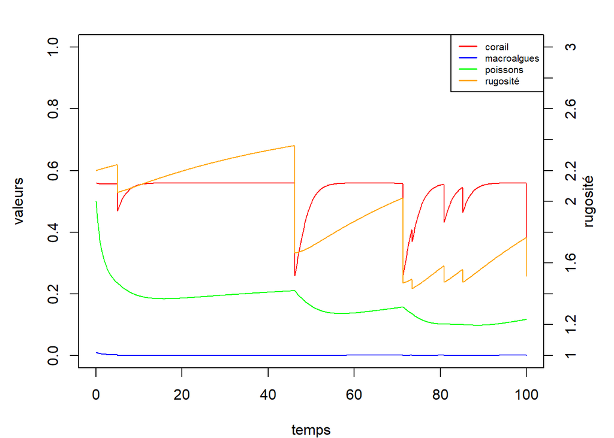

```
## [1] 0.3627353 1.5146189
```

```r
corailstochastique <- function (R0,f,lambda=1/30,impact=2,dt=1,graph=FALSE){
  #on instaure une étendue de temps
  tmax <- 100
  t <- 0
  #le temps au dernier ouragan
  to <- 0

  #on pose les valeurs de départ et les paramètres
  C <- 0.56
  M <- 0.01
  Y <- 0.43
  R <- R0
  P <- 0.5
  a<-0.1
  g<-0.8
  d<-0.44
  r<-1
  f<-f
  s<-0.49
  ca<--(3.21)
  cb<-3.65
  kmax<-17.745
  delta<-4.557
  v<-0.9877
  hG<-0.03
  hE<-0.01
  o <- 0.05
  mH <- 0.8

  #on initie les vecteurs de résultats
  vecC <- C
  vecM <- M
  vecY <- Y
  vecR <- R
  vecP <- P

  while (t<tmax){

    #on effectue le tirage pour déterminer si il y a ou pas ouragan
    ouragan <- pmin(rpois(1,lambda*dt),1)
    #si oui ou non, on ajuste dq
    if (ouragan==1){

      #on calcule le temps depuis le dernier ouragan
      te <- t - to

      #on sauve le nouveau temps de dernier ouragan
      to <- t

      #on calcule F
      F <- pmin(0.0512 + 0.0176*te, 0.5)

      #différents dommage selon valeur d'impact
      if (impact==3){
        #on calcule les dommages d'un fort ouragan
        dommC <- C*(F + o*runif(1))
        dommM <- M*mH
        dommR <- (R-1)*0.5
      }
      if (impact==2){
        #on calcule les dommages d'un moyen ouragan
        dommC <- C*(F + o*runif(1))
        dommM <- M*mH
        dommR <- (R-1)*(F + o*runif(1))
      }
      if (impact==1){
        #on calcule les dommages d'un faible ouragan
        dommC <- 0
        dommM <- M*mH
        dommR <- (R-1)*0.05
      }
    }else{
      dommC <- 0
      dommM <- 0
      dommR <- 0
    }

    #on calcule les changements
    dM <- ((a)*M*C - ((1)*P*M/(M+Y)) + (g)*M*Y)*dt - dommM
    dC <- ((r)*Y*C - (d)*C - (a)*M*C)*dt - dommC
    dP <- ((s)*P*(1 - (P/((((ca+cb*R)/kmax)*((delta*(M+Y))/(1+v*(M+Y))))))) -(f*s)*P)*dt
    dR <- ((hG)*C*(3 - R) - (hE)*(1 - C)*(R - 1))*dt - dommR

    #on effectue les changements
    M <- pmax(M + dM,0.0001)
    C <- pmax(C + dC,0.0001)
    Y <- 1 - M - C
    R <- R + dR
    P <- pmax(P + dP, 0.0001)

    #on sauve les nouvelles valeurs dans leur vecteurs
    vecC <- c(vecC,C)
    vecM <- c(vecM,M)
    vecY <- c(vecY,Y)
    vecR <- c(vecR,R)
    vecP <- c(vecP,P)

    #on fait avancer le temps
    t <- t + dt
  }
  #si on veut afficher les graphiques, on met TRUE à l'argument graph =
  if (graph==TRUE){
    #on affiche le premier plot, avec la trajectoire du corail
    plot(seq(0,tmax,length.out = length(vecC)),vecC, type="l", col="red", ylim=c(0,1),
         xlab= "temps", ylab="valeurs")
    #on ajoute un axe secondaire pour la rugosité
    axis(side = 4,at= seq(0,1,0.1),labels = seq(1,3,0.2), )
    mtext("rugosité", side = 4, line = 2, col = "black", cex = 1)
    #on affiche les différentes lignes
    lines(seq(0,tmax,length.out = length(vecM)),vecM, col="blue")
    lines(seq(0,tmax,length.out = length(vecP)),vecP, col="green")
    lines(seq(0,tmax,length.out = length(vecR)),(vecR-1)/2, col="orange")
    #on ajoute une légende
    legend("topright", legend = c("corail", "macroalgues","poissons","rugosité"),
           col = c("red","blue","green","orange"), lty = c(1, 1),
           lwd = 1.75, bg = "white",cex = 0.65)
  }
  #on affiche le résultat final du couvert de corail ainsi que de la rugosité
  return(c(tail(vecC,1),tail(vecR,1)))
}

#exemple
par(mfrow=c(1,1),mar=c(4,4.5,2,4))
corailstochastique(R0=2.2, f= 0.5, lambda = 1/15,impact = 2,dt=0.1,graph = T)
```

On peut ensuite construire les graphiques du couvert de corail final moyen ainsi que l’écart-type pour un éventail de rugosité initiale entre 1 et 3 et d’effort de pêche entre 0 et 1. La fonction utilisée pour cela est la suivante:

```r
graph.imageC <- function(impact,freq,it=10,pas=0.1){
  #on initie une matrice pour les moyennes et une autre pour les écarts-types
  #pour des images de 21 pixels de hauteur et 26 de largeur
  matC <- matrix(0, nrow = 21,ncol = 26)
  matsd <- matrix(0, nrow = 21,ncol = 26)

  #on fixe les variables constantes
  imp<-impact
  l<-freq
  #Les boucles suivantes font essayer différentes valeurs de R0 et de f
  for (i in 1:21) {
    for (j in 1:26){
      #on amorce un vecteur pour contenir les résultats de chaque réplicat
      res <- vector(length = 0)
      #la boucle pour it nombre de réplicat
      for (z in 1:it) {
        #on calcule R0 et f
        R1 <- i*0.1+0.9
        f0 <- j*0.04-0.04
        #le résultat pour le couvert de corail est [1]
        w <- corailstochastique(R0=R1,f=f0, lambda = l,impact = imp,dt=pas, graph = F)[1]
        res<-c(res,w)
      }
      #on entre la moyenne et l'écart-type de la combinaison dans les matrices correspondantes
      matC[i,j]<-mean(res)
      matsd[i,j]<-sd(res)
    }
  }

  #on fixe les valeurs pour les axes
  x_values <- seq(0, 1, length.out = ncol(matC))
  y_values <- seq(1, 3, length.out = nrow(matC))

  #on affiche les images
  par(mfrow=c(1,2),mar=c(4,4.5,3,5))
  image.plot(x = x_values, y = y_values, t(matC), col = viridis(20),
             xlab = "effort de pêche", ylab = "Rugosité initiale",
             main=c("moyenne de C finale",paste(c("fréq:1/",1/l,", impact:",imp),collapse = "")))
  image.plot(x = x_values, y = y_values, t(matsd), col = viridis(20),
             xlab = "effort de pêche", ylab = "Rugosité initiale",
             main=c("Écart-type de C finale",paste(c("fréq:1/",1/l,", impact:",imp),collapse = "")))
}
```

Idem pour la moyenne ainsi que l’écart-type de la rugosité. La fonction utilisée pour cela est la suivante (ce sont les mêmes étapes que pour graph.imageC, seulement avec [2] pour obtenir la rugosité finale pour `corailstochastique()`, les étapes ne sont donc pas commentées) :

```r
graph.imageR <- function(impact,freq,it=10,pas=0.1, graph=T, max=F){

  matC <- matrix(0, nrow = 21,ncol = 26)
  matsd <- matrix(0, nrow = 21,ncol = 26)

  imp<-impact
  l<-freq
  for (i in 1:21) {
    for (j in 1:26){
      res <- vector(length = 0)
      for (z in 1:it) {
        R1 <- i*0.1+0.9
        f0 <- j*0.04-0.04
        w <- corailstochastique(R0=R1,f=f0, lambda = l,impact = imp,dt=pas, graph = F)[2]
        res<-c(res,w)
      }
      matC[i,j]<-mean(res)
      matsd[i,j]<-sd(res)
    }
  }
  #si on veut afficher les images
  if (graph==TRUE){
    x_values <- seq(0, 1, length.out = ncol(matC))
    y_values <- seq(1, 3, length.out = nrow(matC))
    # Plot the matrix as an image with different colored pixels

    par(mfrow=c(1,2),mar=c(4,4.5,3,5))
    image.plot(x = x_values, y = y_values, t(matC), col = viridis(20),
               xlab = "effort de pêche", ylab = "Rugosité initiale",
               main=c("moyenne de R finale",paste(c("fréq:1/",1/l,", impact:",imp),
                                                  collapse = "")))
    image.plot(x = x_values, y = y_values, t(matsd), col = viridis(20),
               xlab = "effort de pêche", ylab = "Rugosité initiale",
               main=c("Écart-type de R finale",paste(c("fréq:1/",1/l,", impact:",imp),
                                                  collapse = "")))
  }
  #si on veut afficher la moyenne
  if (max==T){
    print(max(matC))
  }
}
```

### Résultat :

Dans la figure 1, on représente les zones d’instabilités entre les populations de macroalgue et le corail. Ainsi, pour chaque rugosité fixe, on regarde pour chaque effort de pêche s’il y a une dominance du corail ou une dominance des macroalgues ou aucune domination. Cette zone qui n’a aucune domination représente la limite de l’effort de pêche pour une rugosité donner.

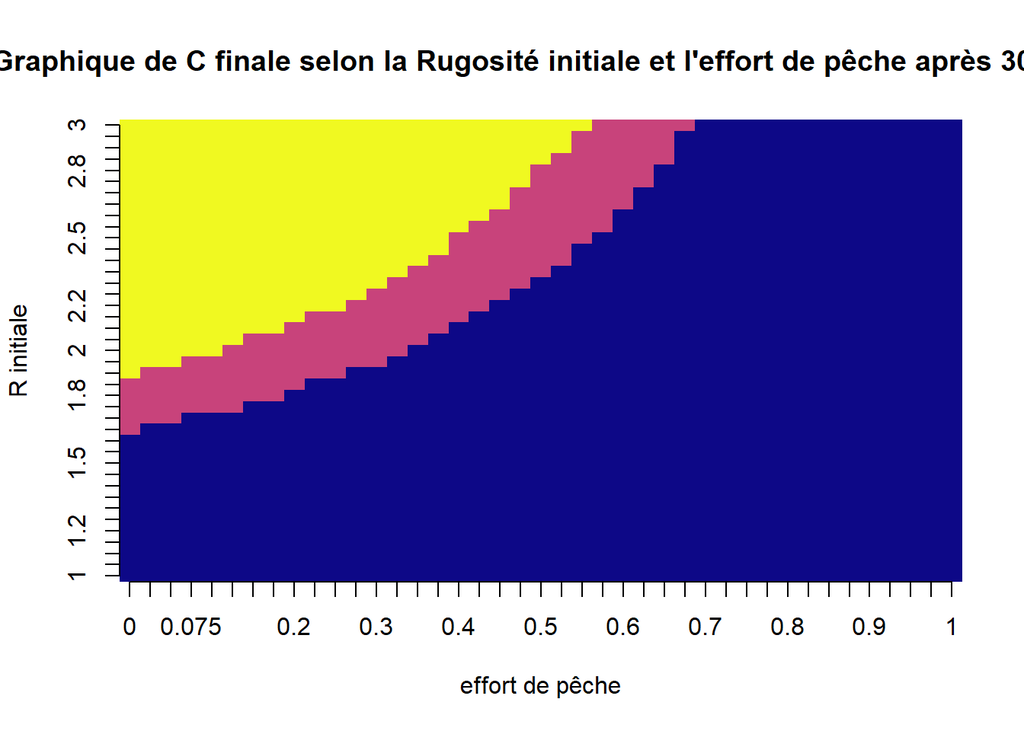

```r
# Affichage pour figure 1
# Définition des noms de lignes et de colonnes
row_names <- paste(seq(1, 3, by = (2 / 40)))
col_names <- paste(seq(0, 1, by = (1 / 40)))

# Attribution des nom de ligne et de colonnes
row.names(coral) <- row_names
colnames(coral) <- col_names

# Créer le graphique avec la matrice en tant que données
image(1:nrow(coral), 1:ncol(coral), t(coral), col = plasma(40),
      xlab = "effort de pêche", ylab = "R initiale", main = "Graphique de C finale selon la Rugosité initiale et l'effort de pêche après 30 ans",axes=F);axis(side = 1, at = 1:ncol(coral), labels = col_names);axis(side = 2, at = 1:nrow(coral), labels = row_names)
```

Dans la figure 2, affichage des graphiques des valeurs d’équilibre après 30 ans de la couverture corallienne en fonction de l’effort de pêche par rapport au taux de croissance des poissons-perroquets (f) pour différentes valeurs de rugosité (R) afin de démontrer les implications de l’effort de pêche sur la couverture des récifs coralliens.

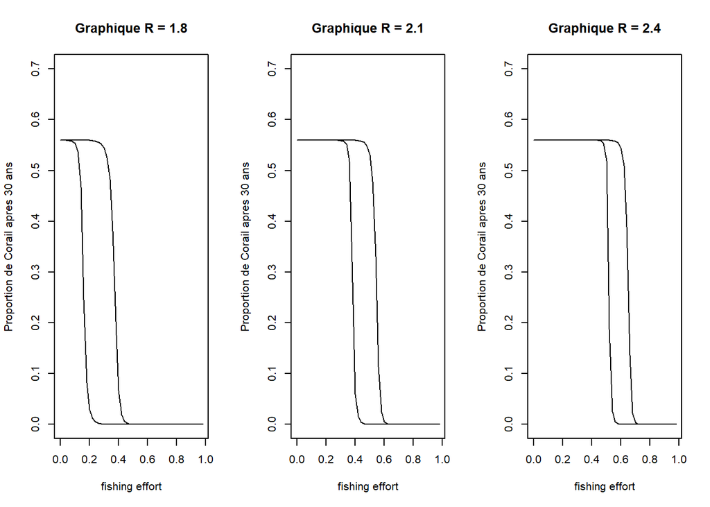

```r
# Affichage pour figure 2
par(mfrow=c(1,3))
plot(x = fish.vec[,1], y = fish.vec[,2],type = "l",ylim = c(0,0.7),xlab = "fishing effort", ylab = "Proportion de Corail apres 30 ans", main = paste("Graphique R =", rug.vec[1]))
lines(x = fish.vec[,1], y = fish.vec[,3])

plot(x = fish.vec[,1], y = fish.vec[,5],type = "l",ylim = c(0,0.7),xlab = "fishing effort", ylab = "Proportion de Corail apres 30 ans", main = paste("Graphique R =", rug.vec[2]))
lines(x = fish.vec[,1], y = fish.vec[,6])

plot(x = fish.vec[,1], y = fish.vec[,8],type = "l",ylim = c(0,0.7),xlab = "fishing effort", ylab = "Proportion de Corail apres 30 ans", main = paste("Graphique R =", rug.vec[3]))
lines(x = fish.vec[,1], y = fish.vec[,9])
```

```r
par(mfrow=c(1,1))
```

On peut ainsi visualiser le résultat pour les 2 situations suivantes, par exemple: la simulation avec ouragans à impacts modérés (2) d’une fréquence faible (30 ans) et la simulation avec ouragans à impacts modérés (2) d’une fréquence élevée (9 ans):

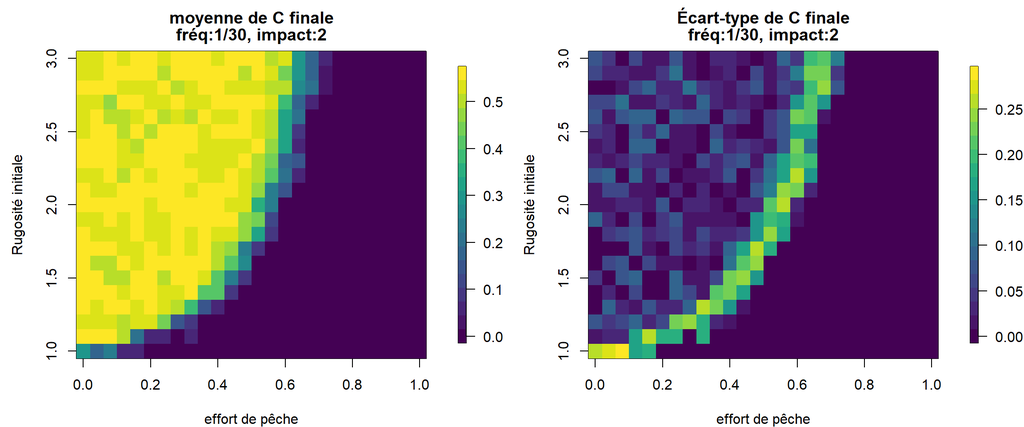

```r
graph.imageC(2,1/30,10,0.1)
```

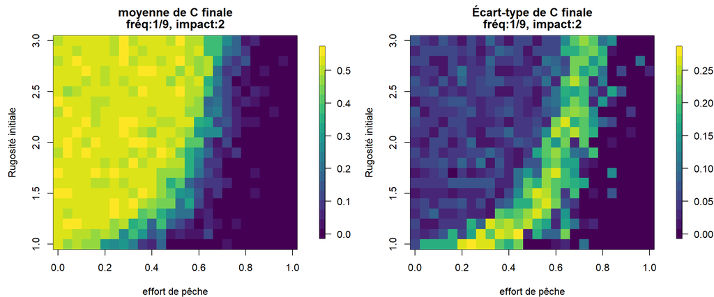

```r
graph.imageC(2,1/9,10,0.1)
```

On peut ensuite bâtir un graphique avec la valeur maximale de rugosité finale pour chacune des 9 simulations possibles d’impact et de fréquence variés:

```r
rugfin<-as.data.frame(matrix(0,nrow = 3, ncol = 3))
colnames(rugfin)<-c("1/9 ans", "1/15 ans", "1/30 ans")
rownames(rugfin)<-c(1,2,3)

rugfin[,1]<-c(graph.imageR(1,1/9,5,0.1,F,T),
              graph.imageR(2,1/9,5,0.1,F,T),
              graph.imageR(3,1/9,5,0.1,F,T))
```

```
## [1] 2.369672
## [1] 1.912927
## [1] 1.695154
```

```r
rugfin[,2]<-c(graph.imageR(1,1/15,5,0.1,F,T),
              graph.imageR(2,1/15,5,0.1,F,T),
              graph.imageR(3,1/15,5,0.1,F,T))
```

```
## [1] 2.478878
## [1] 2.065824
## [1] 1.858427
```

```r
rugfin[,3]<-c(graph.imageR(1,1/30,5,0.1,F,T),
              graph.imageR(2,1/30,5,0.1,F,T),
              graph.imageR(3,1/30,5,0.1,F,T))
```

```
## [1] 2.570639
## [1] 2.362758
## [1] 2.342167
```

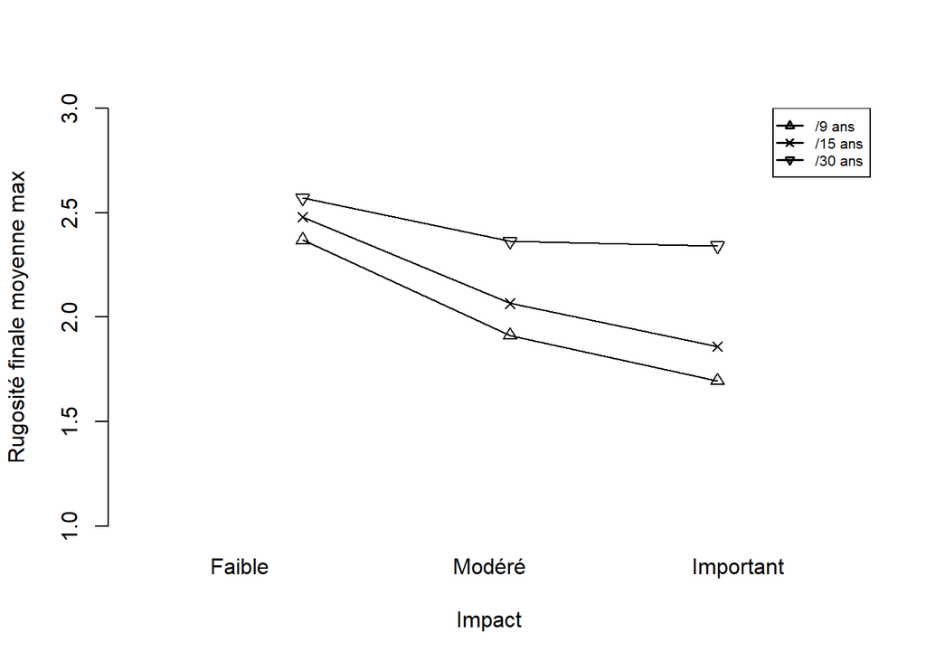

```r
# Définir les catégories
categories <- c("Faible", "Modéré", "Important")

# Créer un diagramme vide
barplot(rep(0, length(categories)), names.arg = categories, ylim = c(1,3),
        xlab = "Impact", ylab = "Rugosité finale moyenne max", main = "")

# Ajout des points et lignes sur le diagramme
points(rep(1:length(categories), each = 1), rugfin[,1],
       pch = 2, col = "black")
points(rep(1:length(categories), each = 1), rugfin[,2],
       pch = 4, col = "black")
points(rep(1:length(categories), each = 1), rugfin[,3],
       pch = 6, col = "black")
lines(rep(1:length(categories), each = 1), rugfin[,1],
       pch = 2, col = "black")
lines(rep(1:length(categories), each = 1), rugfin[,2],
       pch = 4, col = "black")
lines(rep(1:length(categories), each = 1), rugfin[,3],
       pch = 6, col = "black")
#on ajoute la légende
legend("topright", legend = c("/9 ans", "/15 ans","/30 ans"),
       col = c("black","black","black"), pch = c(2,4,6), lty = c(1, 1),
       lwd = 1.5, bg = "white",cex = 0.65)
```